# Some Ideas on Soil Color Signatures

D.E. Beaudette

2026-01-23

# Note

All of these functions will be simplified / documented in the near future, stay tuned.

# Introduction

Pending.

## TODO

- integrate ideas from [colordistance package](https://cran.r-project.org/web/packages/colordistance/vignettes/colordistance-introduction.html)
- what is appropriate rescaling of L?
- use *Δ**E*<sub>00</sub> metric color distances via [farver package](https://github.com/thomasp85/farver)

# Examples

```r
library(aqp)
library(farver)
library(cluster)
library(ape)
library(colorspace)
library(soilDB)
library(sharpshootR)
```

## Colors from Official Series Descriptions

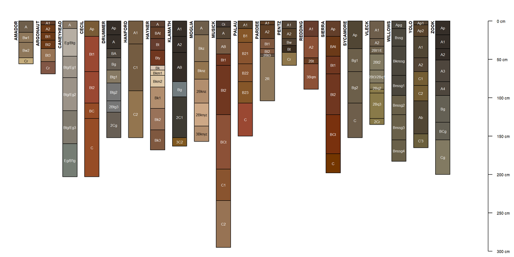

```r
s.list <- c('amador', 'redding', 'pentz', 'willows', 'pardee', 'yolo', 'hanford', 'cecil', 'sycamore', 'KLAMATH', 'MOGLIA', 'vleck', 'drummer', 'CANEYHEAD', 'musick', 'sierra', 'HAYNER', 'zook', 'argonaut', 'PALAU')

# get these soil series
s <- fetchOSD(s.list)

# check
par(mar = c(0, 0, 0, 1))
plotSPC(s, name.style = 'center-center', width = 0.33)
```

Look at full range of OSD colors in this set.

Colors, arranged by *Δ**E*<sub>00</sub>.

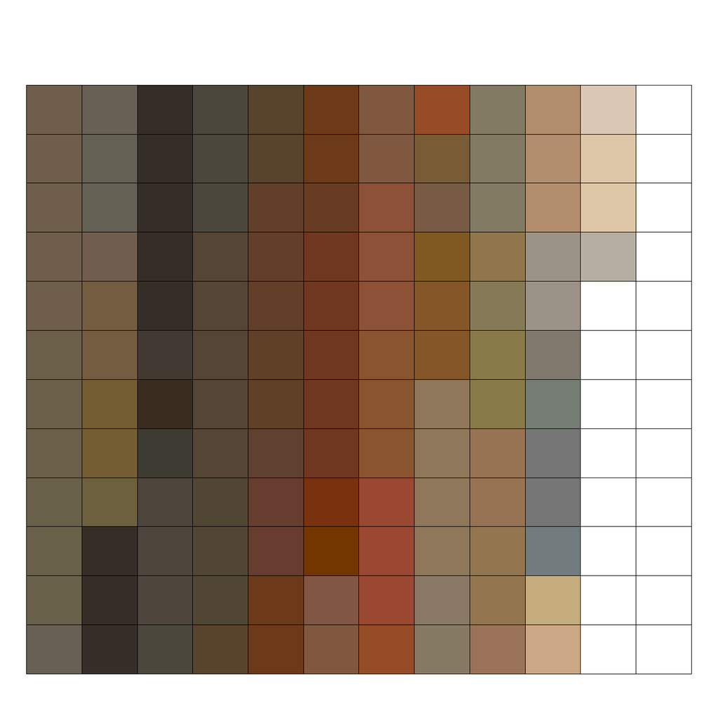

```r
previewColors(s$soil_color)
```

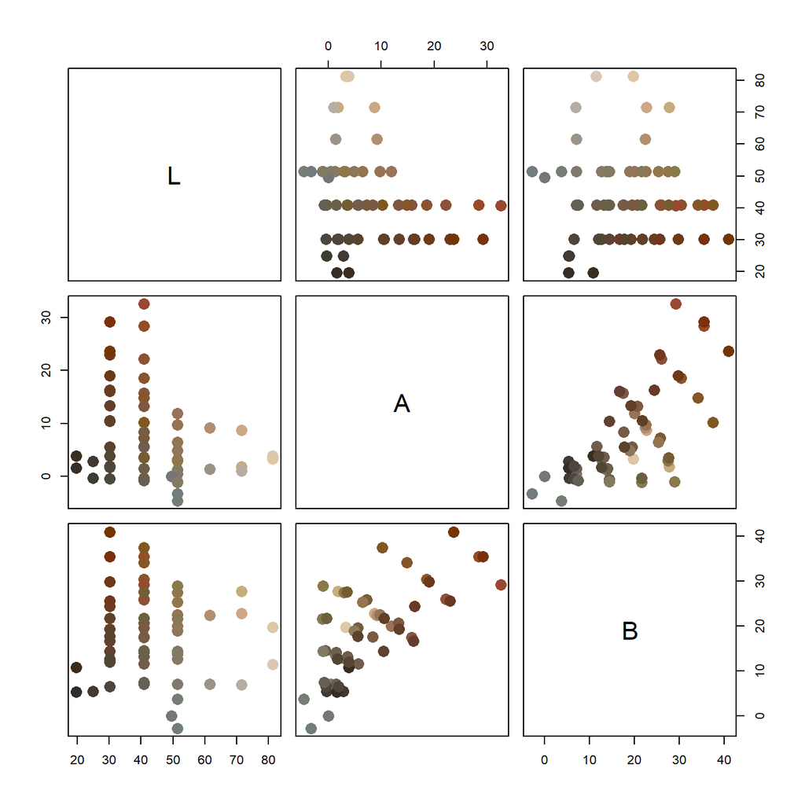

```r
rgb.colors <- munsell2rgb(s$hue, s$value, s$chroma, return_triplets = TRUE)
lab.colors <- as(sRGB(rgb.colors[['r']], rgb.colors[['g']], rgb.colors[['b']]), 'LAB')@coords
cols <- cbind(rgb.colors, lab.colors)
cols <- na.omit(cols)
cols <- as.data.frame(cols)
pairs(~ L + A + B, data=cols, pch=16, cex=2, col=rgb(cols$r, cols$g, cols$b))
```

### Soil Color Signature by “Pigment Proportions”

Compute proportions of white, red, green, yellow, and blue “pigments” based on the CIE LAB representation of soil colors distributed over horizons, weighted by horizon thickness. Pigment proportions are used so that shallow soils can be compared with deep soils. Each row is an observation, columns describe the multivariate soil color signature.

```r
pig <- soilColorSignature(s, color = 'soil_color', method = 'colorBucket')

knitr::kable(head(pig), digits = 3, row.names = FALSE)
```

| id | .white.pigment | .red.pigment | .green.pigment | .yellow.pigment | .blue.pigment |
| --- | --- | --- | --- | --- | --- |
| AMADOR | 0.693 | 0.052 | 0.000 | 0.255 | 0 |
| ARGONAUT | 0.485 | 0.201 | 0.000 | 0.313 | 0 |
| CANEYHEAD | 0.873 | 0.012 | 0.015 | 0.099 | 0 |
| CECIL | 0.405 | 0.277 | 0.000 | 0.317 | 0 |
| DRUMMER | 0.848 | 0.029 | 0.000 | 0.123 | 0 |
| HANFORD | 0.617 | 0.085 | 0.000 | 0.298 | 0 |

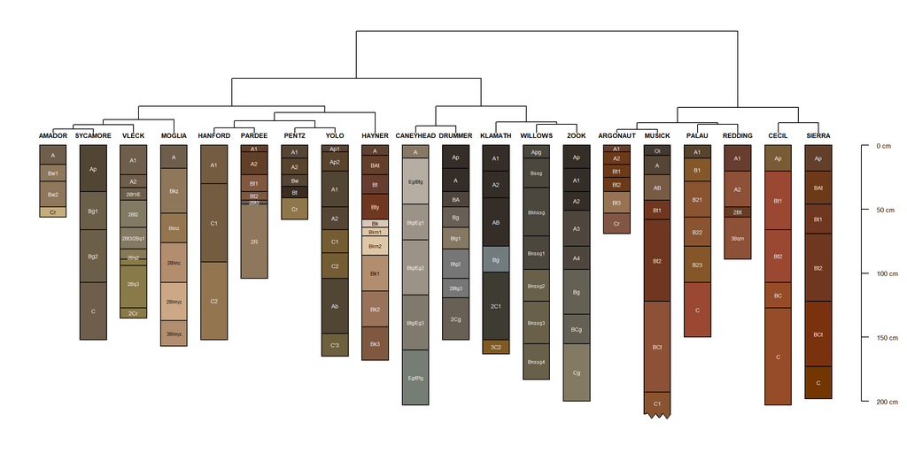

```r
# move row names over for distance matrix
row.names(pig) <- pig[, 1]


d <- daisy(pig[, -1], stand = FALSE, metric = 'euclidean')
dd.colorBucket <- diana(d)


par(mar=c(0,0,1,1))
plotProfileDendrogram(s, dd.colorBucket, scaling.factor = 0.004, y.offset = 0.04, width = 0.33, cex.names = 0.45, shrink = TRUE, name.style = 'center-center', max.depth = 210)
```

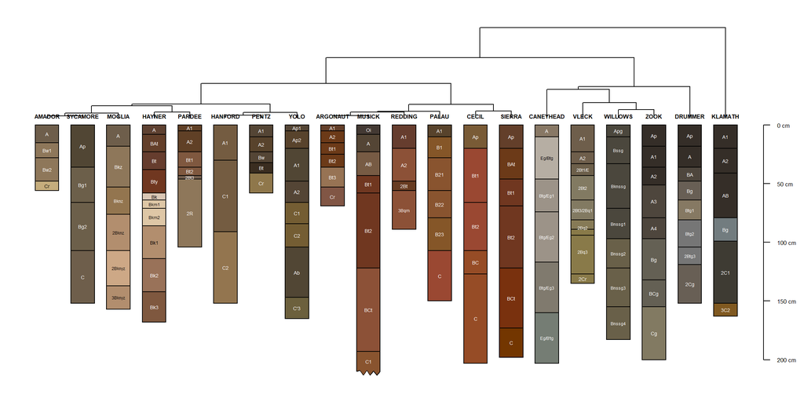

```r
d <- daisy(pig[, -1], stand = TRUE, metric = 'euclidean')
dd.colorBucket <- diana(d)

par(mar=c(0,0,1,1))
plotProfileDendrogram(s, dd.colorBucket, scaling.factor = 0.08, width = 0.33, cex.names = 0.45, shrink = TRUE, name.style = 'center-center', max.depth = 210)
```

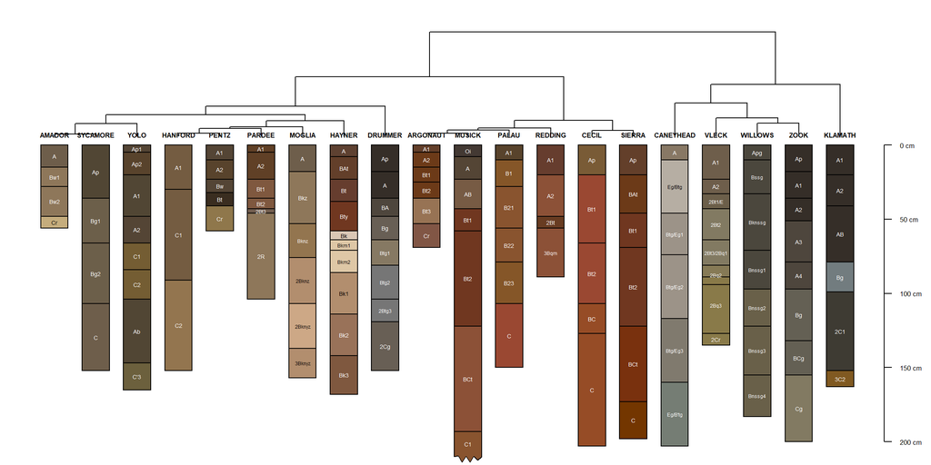

```r
d <- daisy(pig[, -1], weights = c(0.25, 1, 1, 1, 1), metric = 'gower')
dd.colorBucket <- diana(d)

par(mar=c(0,0,1,1))
plotProfileDendrogram(s, dd.colorBucket, scaling.factor = 0.006, width = 0.33, cex.names = 0.45, shrink = TRUE, name.style = 'center-center', max.depth = 210)
```

### Soil Color Signature by “Depth Slices”

Extract CIE LAB coordinates at the 10th, 50th, and 90th percentiles of horizon mid-points. Each row is an observation, columns describe the multivariate soil color signature.

```r
pig <- soilColorSignature(s, color = 'soil_color', method = 'depthSlices')

knitr::kable(head(pig), digits = 3, row.names = FALSE)
```

| id | A.1 | A.2 | A.3 | B.1 | B.2 | B.3 | L.1 | L.2 | L.3 |
| --- | --- | --- | --- | --- | --- | --- | --- | --- | --- |
| AMADOR | 3.362 | 4.617 | 1.854 | 13.323 | 19.328 | 27.905 | 40.960 | 51.502 | 71.742 |
| ARGONAUT | 13.269 | 19.196 | 15.752 | 19.318 | 29.954 | 17.198 | 30.383 | 30.172 | 40.869 |
| CANEYHEAD | 3.052 | 1.389 | -4.803 | 12.731 | 7.023 | 3.869 | 51.407 | 61.415 | 51.502 |
| CECIL | 7.608 | 32.614 | 28.139 | 25.976 | 29.267 | 35.870 | 40.953 | 40.890 | 40.974 |
| DRUMMER | 1.983 | 1.777 | 1.777 | 5.042 | 7.041 | 7.041 | 19.500 | 40.880 | 40.880 |
| HANFORD | 5.906 | 5.906 | 6.626 | 19.280 | 19.280 | 25.419 | 40.842 | 40.842 | 51.289 |

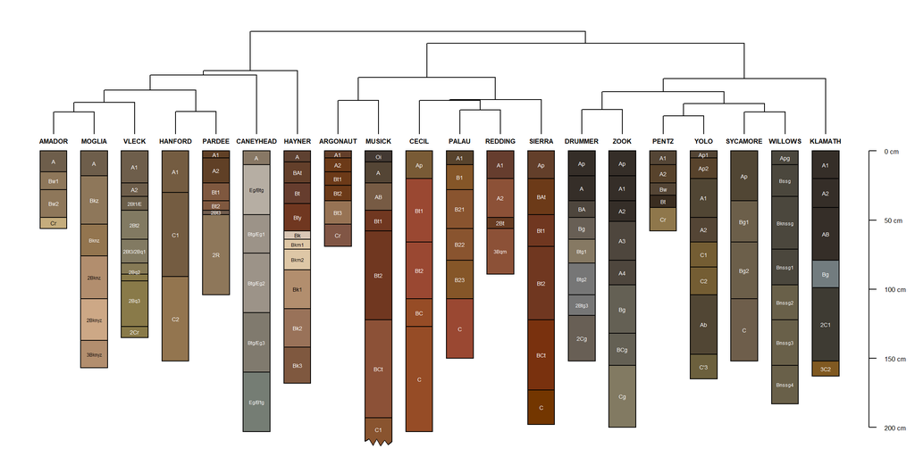

```r
# move row names over for distance matrix
row.names(pig) <- pig[, 1]
d <- daisy(pig[, -1], stand = FALSE)
dd.depthSlices <- diana(d)


par(mar=c(0,0,1,1))
plotProfileDendrogram(s, dd.depthSlices, scaling.factor = 0.48, width = 0.33, cex.names = 0.45, shrink = TRUE, name.style = 'center-center', max.depth = 210)
```

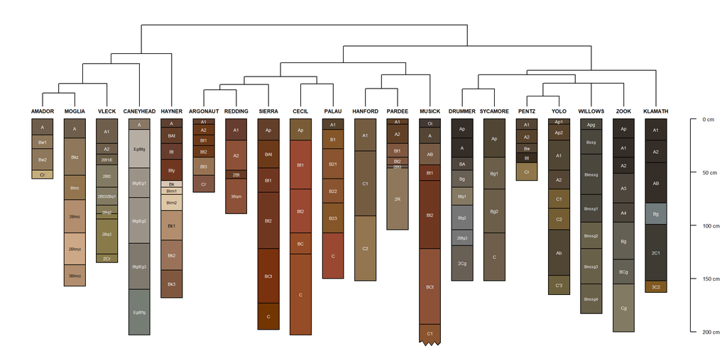

```r
d <- soilColorSignature(s, color = 'soil_color', method = 'depthSlices', perceptualDistMat = TRUE)
dd.depthSlices <- diana(d)

par(mar=c(0,0,1,1))
plotProfileDendrogram(s, dd.depthSlices, width = 0.33, cex.names = 0.45, shrink = TRUE, name.style = 'center-center', max.depth = 210)
```

## Soil Color Signature by “PAM”

Select *k*-medoids (partitioning around medoids algorithm) from all possible colors within the profile or depth interval and use those CIE LAB coordinates as the signature. Each row is an observation, columns describe the multivariate soil color signature.

```r
pig <- soilColorSignature(s, color = 'soil_color', method = 'pam', pam.k = 3)

knitr::kable(head(pig), digits = 3, row.names = FALSE)
```

| id | A.1 | A.2 | A.3 | B.1 | B.2 | B.3 | L.1 | L.2 | L.3 |
| --- | --- | --- | --- | --- | --- | --- | --- | --- | --- |
| AMADOR | 3.362 | 4.617 | 1.854 | 13.323 | 19.328 | 27.905 | 40.960 | 51.502 | 71.742 |
| ARGONAUT | 19.196 | 15.752 | 10.064 | 29.954 | 17.198 | 22.654 | 30.172 | 40.869 | 51.285 |
| CANEYHEAD | 0.102 | -4.803 | 1.389 | 7.398 | 3.869 | 7.023 | 51.428 | 51.502 | 61.415 |
| CECIL | 32.614 | 7.608 | 28.139 | 29.267 | 25.976 | 35.870 | 40.890 | 40.953 | 40.974 |
| DRUMMER | 1.983 | 1.777 | 0.000 | 5.042 | 7.041 | 0.000 | 19.500 | 40.880 | 49.637 |
| HANFORD | 5.906 | 6.626 | 6.626 | 19.280 | 25.419 | 25.419 | 40.842 | 51.289 | 51.289 |

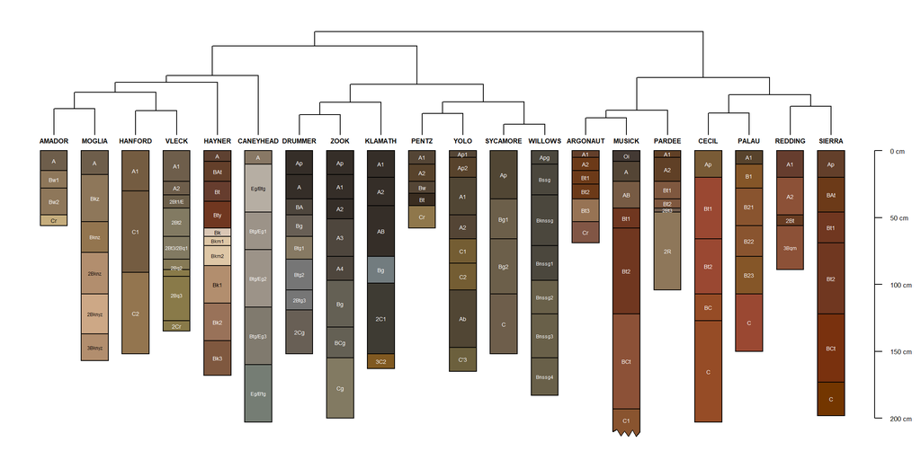

```r
# move row names over for distance matrix
row.names(pig) <- pig[, 1]
d <- daisy(pig[, -1], stand = FALSE)
dd.pam <- diana(d)

par(mar=c(0,0,1,1))
plotProfileDendrogram(s, dd.pam, width = 0.33, cex.names = 0.45, shrink = TRUE, name.style = 'center-center', max.depth = 210)
```

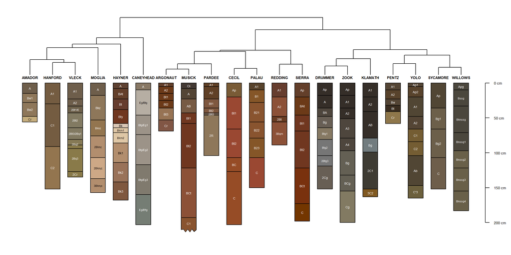

```r
d <- soilColorSignature(s, color = 'soil_color', method = 'pam', perceptualDistMat = TRUE)
dd.pam <- diana(d)

par(mar=c(0,0,1,1))
plotProfileDendrogram(s, dd.pam, width = 0.33, cex.names = 0.45, shrink = TRUE, name.style = 'center-center', max.depth = 210)
```

## Comparison

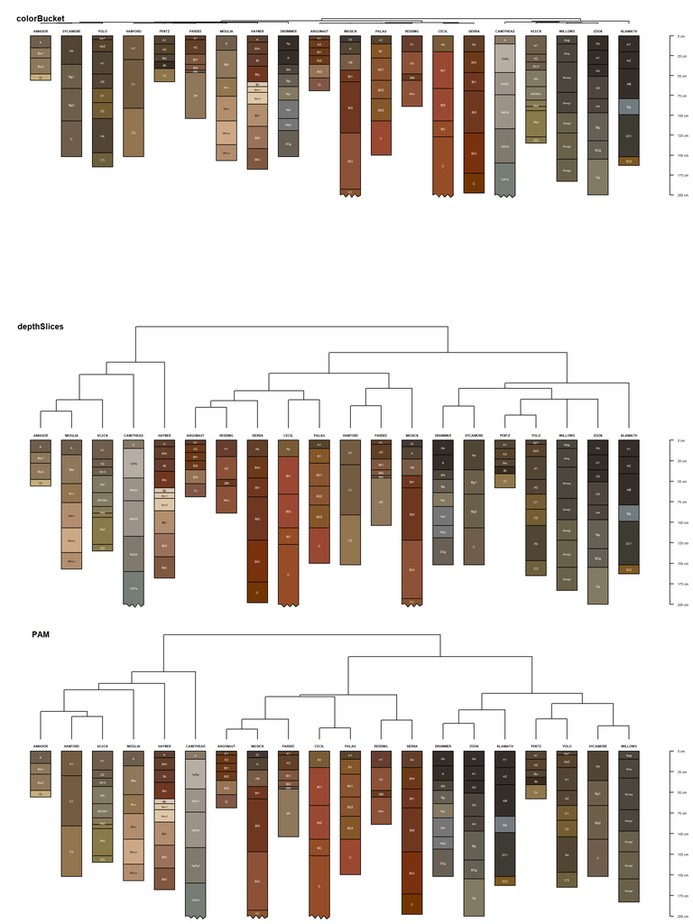

```r
par(mfrow = c(3, 1), mar=c(0,0,1,1))

plotProfileDendrogram(s, dd.colorBucket, dend.y.scale = 24.5, scaling.factor = 0.07, y.offset = 1.1, width = 0.33, cex.names = 0.45, shrink = TRUE, name.style = 'center-center', max.depth = 200)
mtext('colorBucket', side = 3, at = 1, line = -2, cex = 0.85, font = 2)

plotProfileDendrogram(s, dd.depthSlices, dend.y.scale = 122, scaling.factor = 0.36, y.offset = 5.5, width = 0.33, cex.names = 0.45, shrink = TRUE, name.style = 'center-center', max.depth = 200)
mtext('depthSlices', side = 3, at = 1, line = -2, cex = 0.85, font = 2)

plotProfileDendrogram(s, dd.pam, dend.y.scale = 128, scaling.factor = 0.38, y.offset = 5.5, width = 0.33, cex.names = 0.45, shrink = TRUE, name.style = 'center-center', max.depth = 200)
mtext('PAM', side = 3, at = 1, line = -2, cex = 0.85, font = 2)
```

## Soil Color Art

Using the distance matrix / clustering from above.

```r
d <- soilColorSignature(s, color = 'soil_color', method = 'pam', perceptualDistMat = TRUE)
dd <- diana(d)
```

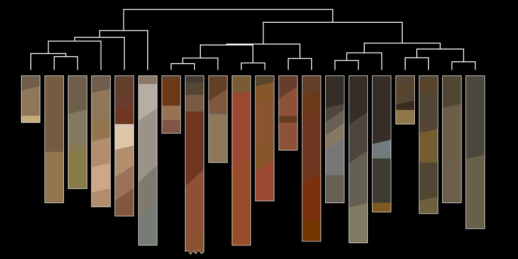

```r
# adjust margins and default colors
par(mar = c(0, 0, 0, 0), bg = 'black', fg = 'white', lend = 2)

# hang profiles from dendrogram
# note customization via arguments passed to plotSPC
plotProfileDendrogram(
  s, dd, scaling.factor = 0.67, y.offset = 5, dend.color = 'white', dend.width = 2,
  width = 0.4, hz.distinctness.offset = 'hzd',
  max.depth = 210,
  name = NA, divide.hz = FALSE, print.id = FALSE, depth.axis = FALSE,
)
```

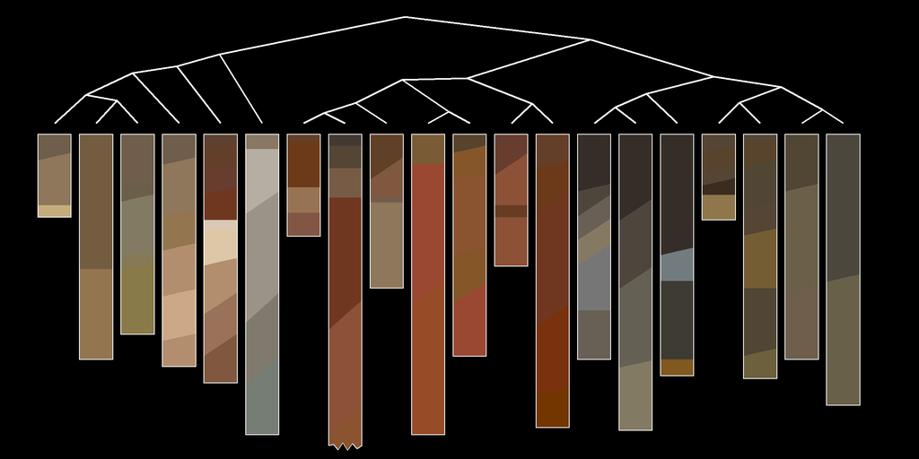

```r
par(mar = c(0, 0, 0, 0), bg = 'black', fg = 'white', lend = 1)

# hang profiles from dendrogram
# note customization via arguments passed to plotSPC
plotProfileDendrogram(
  s, dd, scaling.factor = 0.67, y.offset = 5, dend.color = 'white', dend.width = 2,
  dend.type = 'cladogram',
  width = 0.4, hz.distinctness.offset = 'hzd',
  max.depth = 210,
  name = NA, divide.hz = FALSE, print.id = FALSE, depth.axis = FALSE,
)
```

## Soil Profile Sketch Ordination

Arrange OSD sketches according to locations defined by non-metric multidimensional scaling (ordination) of pair-wise distances. Needs work.

```r
library(MASS)

# add tiny amount for 0-distance pairs (duplicate profiles)
mds <- sammon(d + 0.001)$points
```

```
## Initial stress        : 0.04592
## stress after  10 iters: 0.02078, magic = 0.500
## stress after  20 iters: 0.02077, magic = 0.500
```

```r
# ensure ordering is preserved:
# profile IDs -> distance matrix -> nMDS
all(row.names(mds) == profile_id(s))
```

```
## [1] TRUE
```

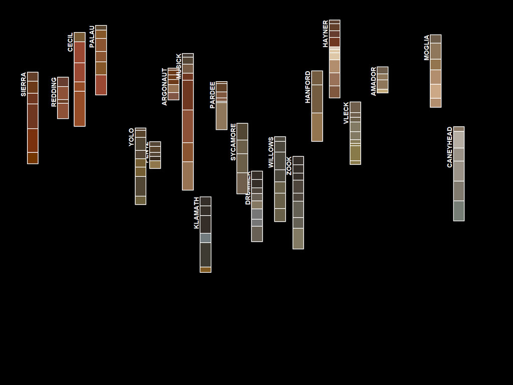

```r
# re-scale nMDS axis 1 to the typical horizontal scale used by plotSPC
xoff <- aqp:::.rescaleRange(mds[, 1], x0 = 1, x1 = length(s))

# adjust to reduce overlap
# with an expansion of the x-axis out to length(s) + 5
set.seed(10110)
xoff.fixed <- fixOverlap(xoff, thresh = 0.65, min.x = 1, max.x = length(s) + 5)

# re-scale nMDS axis 2 to the typical vertical scale used by plotSPC
yoff <- aqp:::.rescaleRange(mds[, 2], x0 = -10, x1 = max(s))

par(mar = c(0.25, 0.25, 0.25, 0.25), bg='black', fg='white')

plotSPC(s, y.offset = yoff, relative.pos = xoff.fixed, width = 0.25, name.style = 'center-center', hz.depths = FALSE, col.label = 'Generalized Horizon Label', print.id = TRUE, name = NA, scaling.factor = 0.8, shrink = TRUE)
```

Arrange OSD sketches according to (approximate) locations defined by non-metric multidimensional scaling (ordination) of pair-wise distances.

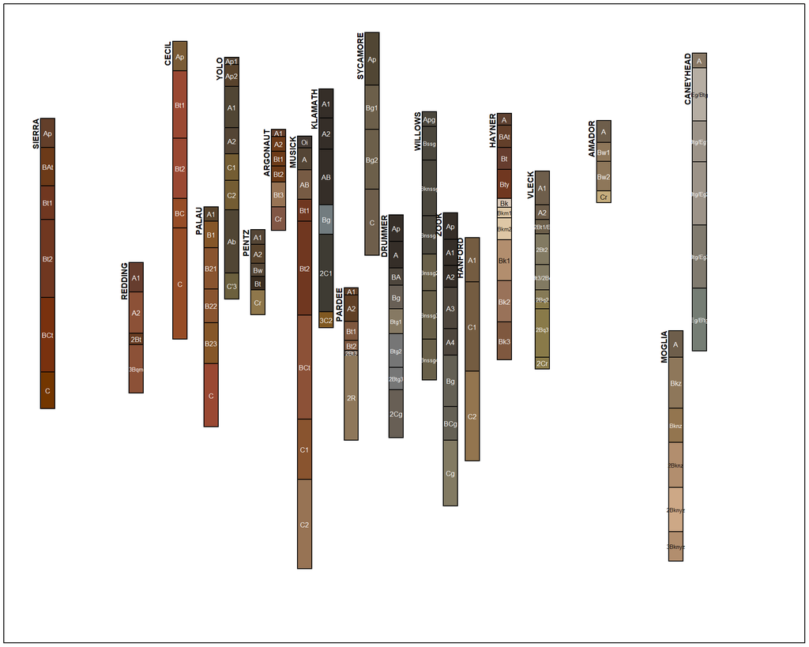

```r
# use re-scaled nMDS coordinates as virtual transect
# adjust to reduce overlap
set.seed(10110)
pos <- alignTransect(xoff, x.min = 1, x.max = length(s) + 4, thresh = 0.7)

par(mar = c(0.25, 0.25, 0.25, 0.25))

plotSPC(s, n = length(s) + 4, y.offset = yoff[pos$order], plot.order = pos$order, relative.pos = pos$relative.pos, width = 0.25, name.style = 'center-center', hz.depths = FALSE, col.label = 'Generalized Horizon Label', print.id = TRUE, scaling.factor = 1.5, shrink = TRUE)

box()
```

This document is based on `aqp` version 2.3.1.